# IODS course project

Santa Neimane

# Introduction to Open Data Science - Course Project

# About the project

I’m happy to start the Open Data Science Course. I expect to deepen my knowledge about the possibilities with R. I found this course when I was looking at the data analysis course list of University of Helsinki. My **Github repository** for the course can be found here: https://github.com/Santa-Neimane/IODS-project

```r
# This is a so-called "R chunk" where you can write R code.

date()
```

```
## [1] "Wed Nov 24 12:24:10 2021"
```

# Regression and model validation

In this part we looked at linear regression to analyse data and how to fit a multiple linear regression model. We also touched upon how to check the assumptions on which the model is based.

Further sections have been written assuming that the reader has an introductory course level understanding of writing and reading R code as well as statistical methods.

```r
date()
```

```
## [1] "Wed Nov 24 12:24:10 2021"
```

In the following analysis I will analyse a dataset originating from a survey *Approaches to Learning* conducted in an introductory statistics course in Finland. More information and meta data can be found here: https://www.mv.helsinki.fi/home/kvehkala/JYTmooc/JYTOPKYS3-meta.txt

Data was set up by:

1. Calculating values for Deep approach (deep), surface approach (surf) and strategic approach (stra) and scaling them back to the original point scale (1-5).
2. Excluding observations where the exam points variable is zero.

Original data and script for data set up can be found: IODS-project/data/create_learning2014.R script. Whilst information about how the values were calculated can be found here: https://www.mv.helsinki.fi/home/kvehkala/JYTmooc/JYTOPKYS2-meta.txt

## Overview

```r
# Read in the prepared data
data <- read.delim("C:/Users/Localadmin_neimane/Desktop/Data Science/OpenDataScience/IODS-project/data/learning2014.txt")

#Set gender as a factor
data$gender <- as.factor(data$gender)

#Show summary of the data set
summary(data)
```

```
##  gender       Age           Attitude          deep            stra
##  F:110   Min.   :17.00   Min.   :14.00   Min.   :1.583   Min.   :1.250
##  M: 56   1st Qu.:21.00   1st Qu.:26.00   1st Qu.:3.333   1st Qu.:2.625
##          Median :22.00   Median :32.00   Median :3.667   Median :3.188
##          Mean   :25.51   Mean   :31.43   Mean   :3.680   Mean   :3.121
##          3rd Qu.:27.00   3rd Qu.:37.00   3rd Qu.:4.083   3rd Qu.:3.625
##          Max.   :55.00   Max.   :50.00   Max.   :4.917   Max.   :5.000
##       surf           Points
##  Min.   :1.583   Min.   : 7.00
##  1st Qu.:2.417   1st Qu.:19.00
##  Median :2.833   Median :23.00
##  Mean   :2.787   Mean   :22.72
##  3rd Qu.:3.167   3rd Qu.:27.75
##  Max.   :4.333   Max.   :33.00
```

The resulting data set consists of 166 observations of 7 variables: gender (110 females, 56 students), age (from 17 till 55 years old, mean age is 26 years), attitude towards statistics, deep approach result (**deep**), surface approach result (**surf**), strategic approach result (**stra**) and exam points.

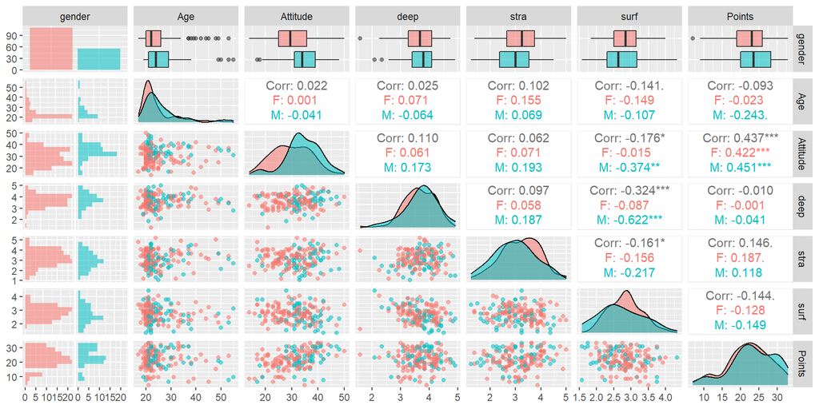

```r
#Call for the needed packages
library(ggplot2)
library(GGally)
#Visually explore the dataset
#Create a more advanced plot matrix with ggpairs()
p <- ggpairs(data, mapping = aes(col=gender, alpha=0.3), lower = list(combo = wrap("facethist", bins = 10)))
p
```

```r
#checking normal distribution
shapiro.test(data$Attitude)
```

```
##
##  Shapiro-Wilk normality test
##
## data:  data$Attitude
## W = 0.99026, p-value = 0.3145
```

```r
shapiro.test(data$deep)
```

```
##
##  Shapiro-Wilk normality test
##
## data:  data$deep
## W = 0.9812, p-value = 0.02371
```

```r
shapiro.test(data$stra)
```

```
##
##  Shapiro-Wilk normality test
##
## data:  data$stra
## W = 0.99068, p-value = 0.3504
```

```r
shapiro.test(data$surf)
```

```
##
##  Shapiro-Wilk normality test
##
## data:  data$surf
## W = 0.99219, p-value = 0.5073
```

```r
shapiro.test(data$Points)
```

```
##
##  Shapiro-Wilk normality test
##
## data:  data$Points
## W = 0.96898, p-value = 0.0008932
```

On the left side you can see the data distribution histograms - majority of the participants were women. Most were in the age between 20 to 30 years old. Variables attitude, stra and surf are in normal distribution according to the Shapiro normality test and histograms. We can observe the correlation between variables **Attitude** and the exam result **Points** (*R$^{2}$=0.44*). Interestingly highest correlation (*R$^{2}$=-0.62*) was observed between variables **deep** and **surf**, but only gender - men subset of the data. Similarly the same, but a weaker correlation (*R$^{2}$=-0.37*) was observed with the variable **surf** and **Attitude**. Whilst some of the boxplots in the upper part of the graph show outliers in the point graphs, for the first analysis we will not remove them since they are not very extreme values. This will be rechecked with model diagnostics.

## Regression model

The task was to fit a regression model where exam points is the target dependent variable and there are 3 explanatory variables. The visual analysis of the highest correlation and linear regression show that model 4 is the best, which includes attitude, stra and age. The following steps to check this were:

1. Build a model with all variables

```r
model1 <- lm(Points ~ gender + Age +Attitude + deep + stra + surf, data = data)
summary(model1)
```

```
##
## Call:
## lm(formula = Points ~ gender + Age + Attitude + deep + stra +
##     surf, data = data)
##
## Residuals:
##      Min       1Q   Median       3Q      Max
## -17.4506  -3.2479   0.3879   3.5243  11.4820
##
## Coefficients:
##             Estimate Std. Error t value Pr(>|t|)
## (Intercept) 18.30246    5.25723   3.481 0.000644 ***
## genderM     -0.05858    0.92985  -0.063 0.949845
## Age         -0.09607    0.05396  -1.780 0.076929 .
## Attitude     0.34430    0.05978   5.760 4.24e-08 ***
## deep        -1.04279    0.78438  -1.329 0.185606
## stra         0.95871    0.55150   1.738 0.084083 .
## surf        -1.10891    0.84467  -1.313 0.191132
## ---
## Signif. codes:  0 '***' 0.001 '**' 0.01 '*' 0.05 '.' 0.1 ' ' 1
##
## Residual standard error: 5.265 on 159 degrees of freedom
## Multiple R-squared:  0.2312, Adjusted R-squared:  0.2021
## F-statistic: 7.967 on 6 and 159 DF,  p-value: 1.599e-07
```

2. Reduce number of factors in the model starting from the least significant. Gender is the least significant variable to explain exam point result so we make a new model without including it.

```r
model2 <- lm(Points ~ Age +Attitude + deep + stra + surf, data = data)
summary(model2)
```

```
##
## Call:
## lm(formula = Points ~ Age + Attitude + deep + stra + surf, data = data)
##
## Residuals:
##      Min       1Q   Median       3Q      Max
## -17.4759  -3.2812   0.3804   3.5381  11.4897
##
## Coefficients:
##             Estimate Std. Error t value Pr(>|t|)
## (Intercept) 18.30059    5.24076   3.492  0.00062 ***
## Age         -0.09650    0.05335  -1.809  0.07234 .
## Attitude     0.34320    0.05699   6.022 1.14e-08 ***
## deep        -1.04374    0.78179  -1.335  0.18375
## stra         0.96551    0.53917   1.791  0.07523 .
## surf        -1.10529    0.84009  -1.316  0.19016
## ---
## Signif. codes:  0 '***' 0.001 '**' 0.01 '*' 0.05 '.' 0.1 ' ' 1
##
## Residual standard error: 5.249 on 160 degrees of freedom
## Multiple R-squared:  0.2311, Adjusted R-squared:  0.2071
## F-statistic:  9.62 on 5 and 160 DF,  p-value: 4.803e-08
```

Variables surf and deep are not significant so they are removed one by one.

```r
model3 <- lm(Points ~ Age + Attitude + deep + stra, data = data)
summary(model3)
```

```
##
## Call:
## lm(formula = Points ~ Age + Attitude + deep + stra, data = data)
##
## Residuals:
##      Min       1Q   Median       3Q      Max
## -17.9941  -3.0839   0.5037   3.5519  11.3298
##
## Coefficients:
##             Estimate Std. Error t value Pr(>|t|)
## (Intercept) 13.24374    3.57079   3.709 0.000286 ***
## Age         -0.08750    0.05303  -1.650 0.100866
## Attitude     0.35388    0.05654   6.259 3.37e-09 ***
## deep        -0.73226    0.74677  -0.981 0.328273
## stra         1.05032    0.53652   1.958 0.051998 .
## ---
## Signif. codes:  0 '***' 0.001 '**' 0.01 '*' 0.05 '.' 0.1 ' ' 1
##
## Residual standard error: 5.261 on 161 degrees of freedom
## Multiple R-squared:  0.2228, Adjusted R-squared:  0.2035
## F-statistic: 11.54 on 4 and 161 DF,  p-value: 2.915e-08
```

And remove variable deep from the model

```r
model4 <- lm(Points ~ Age + Attitude + stra, data = data)
summary(model4)
```

```
##
## Call:
## lm(formula = Points ~ Age + Attitude + stra, data = data)
##
## Residuals:
##      Min       1Q   Median       3Q      Max
## -18.1149  -3.2003   0.3303   3.4129  10.7599
##
## Coefficients:
##             Estimate Std. Error t value Pr(>|t|)
## (Intercept) 10.89543    2.64834   4.114 6.17e-05 ***
## Age         -0.08822    0.05302  -1.664   0.0981 .
## Attitude     0.34808    0.05622   6.191 4.72e-09 ***
## stra         1.00371    0.53434   1.878   0.0621 .
## ---
## Signif. codes:  0 '***' 0.001 '**' 0.01 '*' 0.05 '.' 0.1 ' ' 1
##
## Residual standard error: 5.26 on 162 degrees of freedom
## Multiple R-squared:  0.2182, Adjusted R-squared:  0.2037
## F-statistic: 15.07 on 3 and 162 DF,  p-value: 1.07e-08
```

The Residuals section of the results shows how the actual results differ from the predicted values from the model with specific value region details (minimal value, first quater and so on). Median difference in between the result and model values is 0.33 points. The Intercept shows the mean for the dependent variable (in this model 10.9) when all of the explanatory variables would be 0. The regression equation that explains obtained points in the exam is: Points = 10.9 - (0.09xAge) + (0.35xAttitude) + stra

The three asterisks marks highlights the significance of Attitude. While the dot shows that Age and stra variable p-values are near chosen significance level (0.05). Residual standard error and F statistics shows how well the model can predict data and the degrees of freedom show the amount of data to estimate the parameters (165 datapoints - 3 variables we are looking at). The multiple R squared of the model shows the proportion of the variance in the dependent variable of a regression model that can be explained by the explanatory variables. The value ranges from 0 - 1. In this model the three explanatory variables together account for 22% of the variation in persons obtained exam result points. The result also implies that **Attitude** is associated more strongly with the obtained points in the exam than age and stra (strategic approach).

As Age explanatory variable in the model does not have a statistically significant relationship with the obtained exam points, the variable will be removed from the model.

```r
model5 <- lm(Points ~ Attitude + stra, data = data)
summary(model5)
```

```
##
## Call:
## lm(formula = Points ~ Attitude + stra, data = data)
##
## Residuals:
##      Min       1Q   Median       3Q      Max
## -17.6436  -3.3113   0.5575   3.7928  10.9295
##
## Coefficients:
##             Estimate Std. Error t value Pr(>|t|)
## (Intercept)  8.97290    2.39591   3.745  0.00025 ***
## Attitude     0.34658    0.05652   6.132 6.31e-09 ***
## stra         0.91365    0.53447   1.709  0.08927 .
## ---
## Signif. codes:  0 '***' 0.001 '**' 0.01 '*' 0.05 '.' 0.1 ' ' 1
##
## Residual standard error: 5.289 on 163 degrees of freedom
## Multiple R-squared:  0.2048, Adjusted R-squared:  0.1951
## F-statistic: 20.99 on 2 and 163 DF,  p-value: 7.734e-09
```

Stra variable still has not reached significance threshold.

```r
model6 <- lm(Points ~ Attitude, data = data)
summary(model6)
```

```
##
## Call:
## lm(formula = Points ~ Attitude, data = data)
##
## Residuals:
##      Min       1Q   Median       3Q      Max
## -16.9763  -3.2119   0.4339   4.1534  10.6645
##
## Coefficients:
##             Estimate Std. Error t value Pr(>|t|)
## (Intercept) 11.63715    1.83035   6.358 1.95e-09 ***
## Attitude     0.35255    0.05674   6.214 4.12e-09 ***
## ---
## Signif. codes:  0 '***' 0.001 '**' 0.01 '*' 0.05 '.' 0.1 ' ' 1
##
## Residual standard error: 5.32 on 164 degrees of freedom
## Multiple R-squared:  0.1906, Adjusted R-squared:  0.1856
## F-statistic: 38.61 on 1 and 164 DF,  p-value: 4.119e-09
```

```r
#Determine the AIC value for the models to chose the best fitting one
AIC(model1)
```

```
## [1] 1031.446
```

```r
AIC(model2)
```

```
## [1] 1029.45
```

```r
AIC(model3)
```

```
## [1] 1029.236
```

```r
AIC(model4)
```

```
## [1] 1028.225
```

```r
AIC(model5)
```

```
## [1] 1029.038
```

```r
AIC(model6)
```

```
## [1] 1029.988
```

Even though only attitude is significant, the other factors are close to significance and slightly improve the model (the lowest AIC score) thus the model4 where all 3 explanatory variables were included (age + Attitude + stra) is chosen for deeper analysis.

## Model diagnostics

### Variance Inflation Factor

```r
#Load needed package
library(car)
#Calculate Variance Inflation Factor of the chosen model
vif(model4)
```

```
##      Age Attitude     stra
## 1.010865 1.004083 1.014233
```

Multiple regression assumes that the explanatory variables are independent and do not highly correlate with each other.VIF values are about 1 so we do not need to worry about multicollinearity in the regression model.

### Diagnostic plots and assumptions.

To presume that the built model is valid multiple regression assumptions have to be met. Like the relationship between the dependent and explanatory variables ought to be linear, the residual errors need to be normally distributed and they have a constant variance. These assumptions can be checked with diagnostic plots and tests.

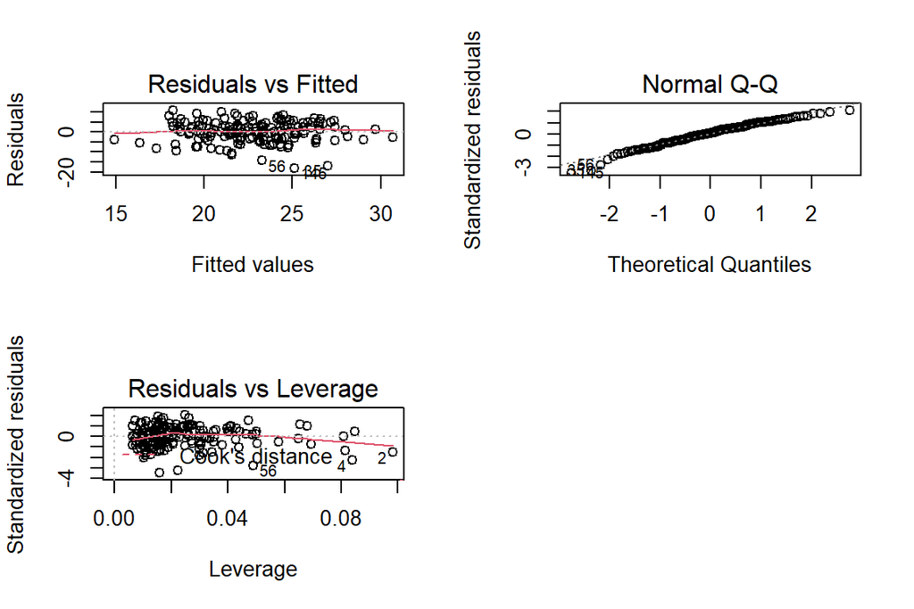

```r
#Plot diagnostic plots (Residuals vs Fitted values, Normal QQ-plot and Residuals vs Leverage) for the chosen model4.
par(mfrow = c(2,2))
plot(model4, which = c(1,2,5))
```

# Logistic regression

In this part we looked at logistic regression to analyse student alcohol consumption data.

```r
date()
```

```
## [1] "Wed Nov 24 12:24:18 2021"
```

In the following analysis I will analyse a data originating from a data set **Student achievement in secondary education of two Portuguese schools**. More information and data can be found here: https://archive.ics.uci.edu/ml/datasets/Student+Performance

Original data and script for data set up can be found: IODS-project/data/create_alc.R script.

Data was set up by:

1. Joining the Mathematics and Portuguese language grade data files
2. Calculating average alcohol use and creating new logical variable high_use which shows alc_use’ is greater than 2.

## Overview

```r
#Read in the prepared data
data <- read.csv("C:/Users/Localadmin_neimane/Desktop/Data Science/OpenDataScience/IODS-project/data/JoinedMathPorData.txt", sep="")

#Show names of the variables
names(data)
```

```
##  [1] "school"        "sex"           "age"           "address"
##  [5] "famsize"       "Pstatus"       "Medu"          "Fedu"
##  [9] "Mjob"          "Fjob"          "reason"        "guardian"
## [13] "traveltime"    "studytime"     "failures.math" "schoolsup"
## [17] "famsup"        "paid.math"     "activities"    "nursery"
## [21] "higher"        "internet"      "romantic"      "famrel"
## [25] "freetime"      "goout"         "Dalc"          "Walc"
## [29] "health"        "absences.math" "G1.math"       "G2.math"
## [33] "G3.math"       "failures.por"  "paid.por"      "absences.por"
## [37] "G1.por"        "G2.por"        "G3.por"        "alc_use"
## [41] "high_use"
```

Data set includes information like, the sex and age (15 - 22), family size (less or more than 3 persons), parent education level, travel time to school, internet access and much more. There are in total 370 observations with 41 column. Variable ending .math or .por indicates the variable being source from Mathematics (.math) or Portuguese language (.por).

## Analysis

For further analysis I will study the relationships between high/low alcohol consumption and the following variables:

1. activities - extra-curricular activities (binary: yes or no)
2. freetime - free time after school (from 1 - very low to 5 - very high)
3. romantic - with a romantic relationship (binary: yes or no)
4. famrel - quality of family relationships (from 1 - very bad to 5 - excellent)

These variables were chosen to test if lack of hobbies and close personal relationships results in increased alcohol consumption among the students. Lack of hobbies is represented with variable **activities** and **freetime**. Whilst absence of close personal relationships can be determined trough variables **romantic** and **famrel**. At this point I expected that with *no* activities and *very high* free time, *no* romantic relationship and *1-very bad* quality of family relationship will result in increased alcohol consumption.

### Graphical exploration

**In the following sections on the left you can see the barplots with the number (count) of the answers, whilst on the right one can see the proportion.** The graph on the left is presented so the reader can see see the data distribution among groups, whilst the right to see the proportions and thus possibility to conclude about the possible factors that affect the alcohol consumption.

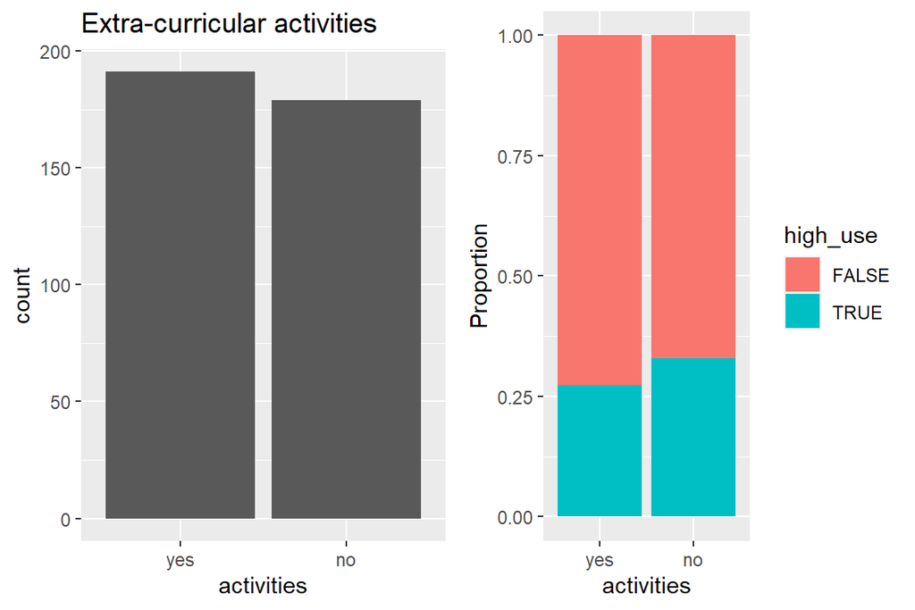

```r
data$famrel <- factor(data$famrel)
data$freetime <- factor(data$freetime)
data$activities <- factor(data$activities)
data$romantic <- factor (data$romantic)

#Load the packages
library(ggplot2)
library(cowplot)
library(dplyr)
# Plot the relationship of activities and alcohol consumption
GraphAct <- ggplot(data,
       aes(x = activities)) +
  geom_bar(position = "stack")+
  ggtitle("Extra-curricular activities")

GraphActProp <- ggplot(data,
       aes(x = activities,
           fill = high_use)) +
  geom_bar(position = "fill") +
  labs(y = "Proportion")

plot_grid(GraphAct, GraphActProp)
```

In the *Extra-curricular activities graphs* we can firstly see that the number of students having and not having activities is similar (~180). The proportion of high alcohol consumption is among students with no extra-curricular activities is slightly higher.

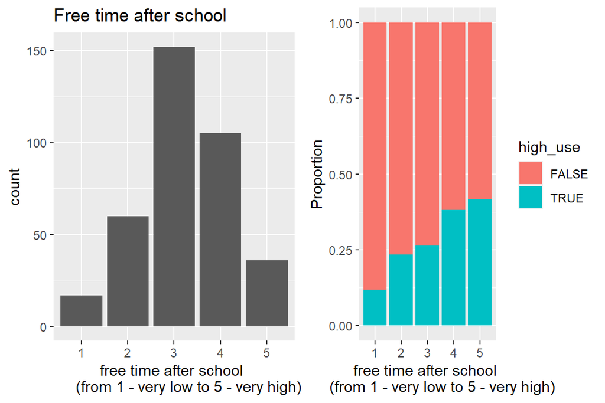

```r
# Plot the relationship of freetime and alcohol consumption
GraphFTime <- ggplot(data,
       aes(x = freetime)) +
  geom_bar(position = "stack")+
  ggtitle("Free time after school")+
  labs(x = "free time after school
       (from 1 - very low to 5 - very high)")

GraphFTimeProp <- ggplot(data,
       aes(x = freetime,
           fill = high_use)) +
  geom_bar(position = "fill") +
  labs(y = "Proportion")+
  labs(x = "free time after school
       (from 1 - very low to 5 - very high)")

plot_grid(GraphFTime, GraphFTimeProp)
```

The second graph **Free time after school** division in free time groups is not equal, there are more students that had an average amount free time after school than with a high and very low amount of free time. The graph with proportions clearly approve the hypotheses that alcohol consumtion increases with more available free time.

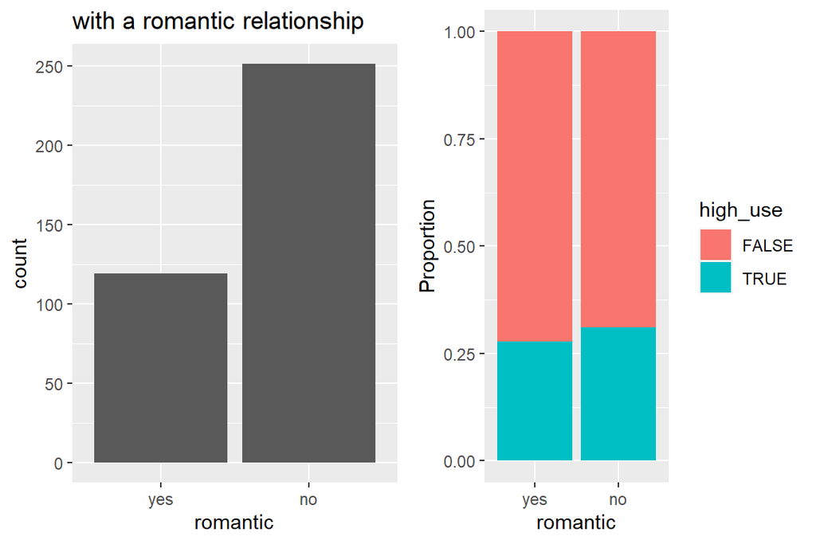

```r
# Plot the relationship of romantic relationship and alcohol consumption
GraphRom <- ggplot(data,
       aes(x = romantic)) +
  geom_bar(position = "stack")+
  ggtitle("with a romantic relationship")

GraphRomProp <- ggplot(data,
       aes(x = romantic,
           fill = high_use)) +
  geom_bar(position = "fill") +
  labs(y = "Proportion")

plot_grid(GraphRom, GraphRomProp)
```

In the third graph **with a romantic relationship** we can see that most of the students did not have a romantic relationship. Whilst proportion graph shows that the students with romantic relationship had only slightly lower proportion of students with high alcohol consumption.

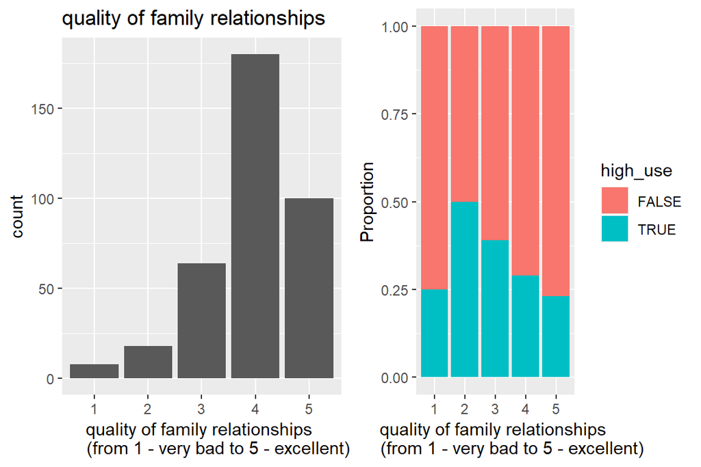

```r
# Plot the relationship of family relationship and alcohol consumption
GraphFamR <- ggplot(data,
       aes(x = famrel)) +
  geom_bar(position = "stack")+
  ggtitle("quality of family relationships")+
  labs(x="quality of family relationships
       (from 1 - very bad to 5 - excellent)")

GraphFamRProp <- ggplot(data,
       aes(x = famrel,
           fill = high_use)) +
  geom_bar(position = "fill") +
  labs(y = "Proportion")+
  labs(x="quality of family relationships
       (from 1 - very bad to 5 - excellent)")

plot_grid(GraphFamR, GraphFamRProp)
```

In the forth **quality of family relationships** graph we can see that most of the students had good and excellent relationships with family. In the proportions we can see that with increased quality of family relationships there are less students that consume high amount of alcohol, thus confirming the hypothesis that students who have good family relationships consume less alcohol. As for the proportion of students with very bad relationships, on the left we can see that the there only few students, perhaps due to this reason the proportion does not fit the general pattern.

### Logistic regression model

In this section multiple models will be built. The best fitting one will be analysed in detail, the predictive power will be explored and the model will be cross-validated. First I will build a model with all of the variables that were selected.

```r
#Seting the chosen variables as factors
data$famrel <- factor(data$famrel)
data$freetime <- factor(data$freetime)
data$activities <- factor(data$activities)
data$romantic <- factor (data$romantic)

#building model with glm() with all of the factors
model1  <- glm(high_use ~ famrel + romantic + freetime + activities, data = data, family=binomial)
#showing summary
summary(model1)
```

```
##
## Call:
## glm(formula = high_use ~ famrel + romantic + freetime + activities,
##     family = binomial, data = data)
##
## Deviance Residuals:
##     Min       1Q   Median       3Q      Max
## -1.4553  -0.8440  -0.6844   1.2657   2.1236
##
## Coefficients:
##              Estimate Std. Error z value Pr(>|z|)
## (Intercept)   -2.4628     1.1240  -2.191   0.0284 *
## famrel2        0.7507     0.9719   0.772   0.4399
## famrel3        0.4070     0.8813   0.462   0.6442
## famrel4       -0.1789     0.8612  -0.208   0.8355
## famrel5       -0.5407     0.8827  -0.613   0.5402
## romanticno     0.1975     0.2571   0.768   0.4424
## freetime2      1.0093     0.8210   1.229   0.2189
## freetime3      1.2523     0.7856   1.594   0.1109
## freetime4      1.8474     0.7925   2.331   0.0197 *
## freetime5      2.0287     0.8423   2.409   0.0160 *
## activitiesno   0.3002     0.2372   1.266   0.2056
## ---
## Signif. codes:  0 '***' 0.001 '**' 0.01 '*' 0.05 '.' 0.1 ' ' 1
##
## (Dispersion parameter for binomial family taken to be 1)
##
##     Null deviance: 452.04  on 369  degrees of freedom
## Residual deviance: 428.30  on 359  degrees of freedom
## AIC: 450.3
##
## Number of Fisher Scoring iterations: 4
```

Activities after school and romantic relationship factors are not significant suggesting there is no association with the probability of having high alcohol consumption.

```r
#the model with glm() without non-significant romantic relationship factor
model2  <- glm(high_use ~ famrel + freetime + activities, data = data, family=binomial)

summary(model2)
```

```
##
## Call:
## glm(formula = high_use ~ famrel + freetime + activities, family = binomial,
##     data = data)
##
## Deviance Residuals:
##     Min       1Q   Median       3Q      Max
## -1.4314  -0.8199  -0.7056   1.2822   2.1381
##
## Coefficients:
##              Estimate Std. Error z value Pr(>|z|)
## (Intercept)   -2.3755     1.1214  -2.118   0.0341 *
## famrel2        0.8276     0.9682   0.855   0.3927
## famrel3        0.4821     0.8773   0.550   0.5826
## famrel4       -0.1132     0.8580  -0.132   0.8950
## famrel5       -0.4541     0.8763  -0.518   0.6043
## freetime2      0.9759     0.8197   1.191   0.2338
## freetime3      1.2253     0.7847   1.562   0.1184
## freetime4      1.8174     0.7913   2.297   0.0216 *
## freetime5      1.9912     0.8406   2.369   0.0179 *
## activitiesno   0.3103     0.2366   1.311   0.1897
## ---
## Signif. codes:  0 '***' 0.001 '**' 0.01 '*' 0.05 '.' 0.1 ' ' 1
##
## (Dispersion parameter for binomial family taken to be 1)
##
##     Null deviance: 452.04  on 369  degrees of freedom
## Residual deviance: 428.89  on 360  degrees of freedom
## AIC: 448.89
##
## Number of Fisher Scoring iterations: 4
```

Also this model does not suggest an association between activities and alcohol consumption.

```r
#the model with glm() without non-significant activities factor
model3  <- glm(high_use ~ famrel + freetime, data = data, family=binomial)

summary(model3)
```

```
##
## Call:
## glm(formula = high_use ~ famrel + freetime, family = binomial,
##     data = data)
##
## Deviance Residuals:
##     Min       1Q   Median       3Q      Max
## -1.3729  -0.8366  -0.6810   1.3462   2.1895
##
## Coefficients:
##             Estimate Std. Error z value Pr(>|z|)
## (Intercept)  -2.1844     1.1042  -1.978   0.0479 *
## famrel2       0.8418     0.9637   0.874   0.3824
## famrel3       0.4810     0.8726   0.551   0.5815
## famrel4      -0.1171     0.8532  -0.137   0.8908
## famrel5      -0.4769     0.8715  -0.547   0.5843
## freetime2     0.9580     0.8208   1.167   0.2431
## freetime3     1.1989     0.7864   1.525   0.1274
## freetime4     1.7913     0.7931   2.258   0.0239 *
## freetime5     1.9117     0.8400   2.276   0.0229 *
## ---
## Signif. codes:  0 '***' 0.001 '**' 0.01 '*' 0.05 '.' 0.1 ' ' 1
##
## (Dispersion parameter for binomial family taken to be 1)
##
##     Null deviance: 452.04  on 369  degrees of freedom
## Residual deviance: 430.62  on 361  degrees of freedom
## AIC: 448.62
##
## Number of Fisher Scoring iterations: 4
```

```r
# Building the simples possible model
model4  <- glm(high_use ~ freetime, data = data, family=binomial)
summary(model4)
```

```
##
## Call:
## glm(formula = high_use ~ freetime, family = binomial, data = data)
##
## Deviance Residuals:
##     Min       1Q   Median       3Q      Max
## -1.0383  -0.7815  -0.7815   1.3893   2.0688
##
## Coefficients:
##             Estimate Std. Error z value Pr(>|z|)
## (Intercept)  -2.0149     0.7528  -2.677  0.00744 **
## freetime2     0.8253     0.8123   1.016  0.30961
## freetime3     0.9853     0.7750   1.271  0.20359
## freetime4     1.5294     0.7791   1.963  0.04965 *
## freetime5     1.6784     0.8252   2.034  0.04195 *
## ---
## Signif. codes:  0 '***' 0.001 '**' 0.01 '*' 0.05 '.' 0.1 ' ' 1
##
## (Dispersion parameter for binomial family taken to be 1)
##
##     Null deviance: 452.04  on 369  degrees of freedom
## Residual deviance: 441.17  on 365  degrees of freedom
## AIC: 451.17
##
## Number of Fisher Scoring iterations: 4
```

```r
#Exploring how model change with removing variables
AIC(model1,model2, model3, model4)
```

```
##        df      AIC
## model1 11 450.2989
## model2 10 448.8948
## model3  9 448.6203
## model4  5 451.1664
```

Model 3 has the lowest AIC score.

```r
anova(model1, model2, model3, model4, test="LRT")
```

```
## Analysis of Deviance Table
##
## Model 1: high_use ~ famrel + romantic + freetime + activities
## Model 2: high_use ~ famrel + freetime + activities
## Model 3: high_use ~ famrel + freetime
## Model 4: high_use ~ freetime
##   Resid. Df Resid. Dev Df Deviance Pr(>Chi)
## 1       359     428.30
## 2       360     428.89 -1  -0.5959  0.44013
## 3       361     430.62 -1  -1.7255  0.18899
## 4       365     441.17 -4 -10.5460  0.03217 *
## ---
## Signif. codes:  0 '***' 0.001 '**' 0.01 '*' 0.05 '.' 0.1 ' ' 1
```

Model4 is significantly different according to the likelihood ratio test.

Data visual exploration coincided with the outputs of models. Factors **freetime** (free time) and **famrel** *(family relationships) effected the probability of alcohol consumption by the students. According to the graphical exploration, Akaike information criterion and likelihood ratio test the best model is model 3 thus it will be used for further analysis.

In the original model3 version we see that the reference value for family relationships is famrel1 (very bad relationship). As we recall this was a rather problematic case, because of the very small amount of students thus we change the reference value from very bad 1 to 3 average. The same problem occurs with the variable freetime thus we change it to average free time to student as well.

```r
#Set the average family relationship and average free time as the reference
data <- within(data, famrel <- relevel(famrel, ref = 3))
data <- within(data, freetime <- relevel(freetime, ref = 3))
#Re-run the model
model3  <- glm(high_use ~ famrel + freetime, data = data, family=binomial)

summary(model3)
```

```
##
## Call:
## glm(formula = high_use ~ famrel + freetime, family = binomial,
##     data = data)
##
## Deviance Residuals:
##     Min       1Q   Median       3Q      Max
## -1.3729  -0.8366  -0.6810   1.3462   2.1895
##
## Coefficients:
##             Estimate Std. Error z value Pr(>|z|)
## (Intercept)  -0.5045     0.3056  -1.650  0.09884 .
## famrel1      -0.4810     0.8726  -0.551  0.58147
## famrel2       0.3608     0.5510   0.655  0.51258
## famrel4      -0.5982     0.3162  -1.892  0.05854 .
## famrel5      -0.9579     0.3620  -2.646  0.00815 **
## freetime1    -1.1989     0.7864  -1.525  0.12735
## freetime2    -0.2409     0.3651  -0.660  0.50941
## freetime4     0.5924     0.2783   2.129  0.03328 *
## freetime5     0.7128     0.3917   1.820  0.06881 .
## ---
## Signif. codes:  0 '***' 0.001 '**' 0.01 '*' 0.05 '.' 0.1 ' ' 1
##
## (Dispersion parameter for binomial family taken to be 1)
##
##     Null deviance: 452.04  on 369  degrees of freedom
## Residual deviance: 430.62  on 361  degrees of freedom
## AIC: 448.62
##
## Number of Fisher Scoring iterations: 4
```

In the summary we can see that going to bad family relationships (famrel2) from average relationships (famrel3) increase the log odds of the student consuming high amounts of alcohol by 0.36. But from average family relationship to excellent (famrel5) relationship decrease the odds by 0.96. Freetime also shows that from average free time (the reference freetime3) to a lot of free time (freetime) the log odds of high alcohol consumption increases by 0.71. On the other hand, from average to very limited amount of free time (freetime1) the log odds to get high alcohol consumption decreases by 1.2. The difference between Null deviance and Residual deviance shows that the model is good fit, since there is a big difference. Residual deviance shows the case when the variables are included, but only intercept value for the null deviance.

### Odds ratios

```r
#calculate odds ratios (OR)
OR <- coef(model3) %>% exp

#calculate confidence intervals (CI)
CI <- confint(model3) %>% exp
#present the odds ratios with their confidence intervals
cbind(OR, CI)
```

```
##                    OR      2.5 %    97.5 %
## (Intercept) 0.6038340 0.32804427 1.0930307
## famrel1     0.6181520 0.08398845 3.0504020
## famrel2     1.4344737 0.48258059 4.2790030
## famrel4     0.5498183 0.29574568 1.0258361
## famrel5     0.3837050 0.18707811 0.7770458
## freetime1   0.3015267 0.04552692 1.1623551
## freetime2   0.7859174 0.37459180 1.5802216
## freetime4   1.8082833 1.04899532 3.1300954
## freetime5   2.0396661 0.93587347 4.3848926
```

### Predictive power

Further we will model prediction ability.

```r
#  calculate the probability of high_use
probabilities <- predict(model3, type = "response")

# add the predicted probabilities
data <- mutate(data, probability = probabilities)


# use the probabilities to make a prediction of high_use
data <- mutate(data, prediction = probability > 0.5)
ResultProbTable <- select(data, freetime, famrel, high_use, probability, prediction)

library(DT)
#Made a smaller more interactive result table otherwise it takes up a lot of space in the document. Feel free to scroll trough it
datatable(ResultProbTable, options = list(pageLength = 5))
```

|  | freetime | famrel | high_use | probability | prediction |
| --- | --- | --- | --- | --- | --- |
| 1 | 3 | 4 | False | 0.249248661568136 | False |
| 2 | 3 | 5 | False | 0.188110108463511 | False |
| 3 | 3 | 4 | True | 0.249248661568136 | False |
| 4 | 2 | 3 | False | 0.32183327787649 | False |
| 5 | 3 | 4 | False | 0.249248661568136 | False |
| 6 | 4 | 5 | False | 0.295262763561655 | False |
| 7 | 4 | 4 | False | 0.375135969050416 | False |
| 8 | 1 | 4 | False | 0.0909971360782648 | False |
| 9 | 2 | 4 | False | 0.206930644645247 | False |
| 10 | 5 | 5 | False | 0.320919112192565 | False |

[output cut: 360 more lines]

```r
# tabulate the target variable versus the predictions
table(high_use = data$high_use, prediction = data$prediction)
```

```
##         prediction
## high_use FALSE TRUE
##    FALSE   245   14
##    TRUE     98   13
```

Of the 259 FALSE values the developed model wrongly assigned 14 to TRUE. Most of the TRUE values model predicted to be FALSE. The probability versus the alcohol use can be seen in the graph.

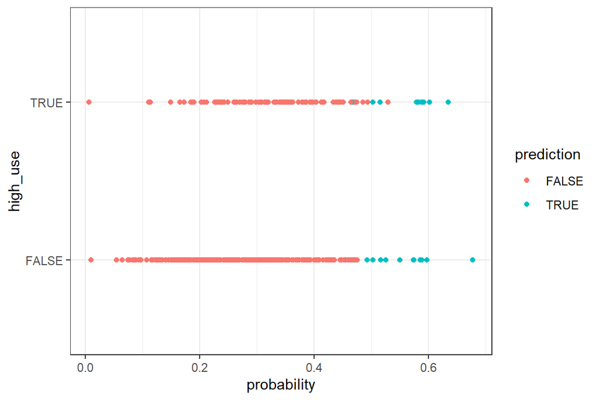

```r
# Graph the results
ggplot(data, aes(x = probability, y = high_use))+
  geom_point(position=position_jitter(h=0.000001,w=0.1), aes(colour = prediction))+
  theme_bw()
```

```r
#jitter has been added since the points closely overlap
```

```r
# tabulate the target variable versus the predictions
table(high_use = data$high_use, prediction = data$prediction) %>% prop.table %>% addmargins
```

```
##         prediction
## high_use      FALSE       TRUE        Sum
##    FALSE 0.66216216 0.03783784 0.70000000
##    TRUE  0.26486486 0.03513514 0.30000000
##    Sum   0.92702703 0.07297297 1.00000000
```

The table above shows how the model incorrectly underestimates proportion of TRUE values and overestimates the FALSE amount of points. In the data set 0.3 are true whilst only model predicted proportion would be much smaller 0.07.

```r
#define average prediction error
loss_func <- function(class, prob) {
  n_wrong <- abs(class - prob) > 0.5
  mean(n_wrong)
}

#calculate the average number of wrong predictions
loss_func(class = data$high_use, prob = data$probability)
```

```
## [1] 0.3027027
```

Total proportion of inaccurately classified individuals is 0.3. And as we saw before most of those are TRUE values that were assigned according to the model to FALSE. Still this model would better predict (~70%) than random guessing with 50% probability.

### Cross-validation

Here 10-fold cross-validation is used to determine the models predictive power by sub-setting the original data set and testing the the models predictive power against the part of the data (sub-set) that was not used to build the model.

```r
# K-fold cross-validation
library(boot)
cv <- cv.glm(data = data, cost = loss_func, glmfit = model3, K = 10)

# average number of wrong predictions in the cross validation
cv$delta[1]
```

```
## [1] 0.3135135
```

# Clustering and classification

## Data preparation

In this task we will use data from the MASS package, the Boston data set. This data set describes housing values in suburbs of Boston. All the information about this data set can be found here: https://stat.ethz.ch/R-manual/R-devel/library/MASS/html/Boston.html In short, data set consists of multiple different variables, like nitrogen oxides concentration, per capita crime rate by town, pupil-teacher ratio by town and others. Abbreviations can be seen here: **crim** - per capita crime rate by town.

**zn** - proportion of residential land zoned for lots over 25,000 sq.ft.

**indus** - proportion of non-retail business acres per town.

**chas** - Charles River dummy variable (= 1 if tract bounds river; 0 otherwise).

**nox** - nitrogen oxides concentration (parts per 10 million).

**rm** - average number of rooms per dwelling.

**age** - proportion of owner-occupied units built prior to 1940.

**dis** - weighted mean of distances to five Boston employment centres.

**rad** - index of accessibility to radial highways.

**tax** - full-value property-tax rate per $10,000.

**ptratip** - pupil-teacher ratio by town.

**black** - 1000(Bk - 0.63)^2 where Bk is the proportion of blacks by town.

**lstat** - lower status of the population (percent).

**medv** - median value of owner-occupied homes in $1000s.

```r
#Load the needed package
library(MASS)
```

```r
library(ggplot2)
library(GGally)
# Load the dataset
data("Boston")

# Explore the structure and the dimensions
dim(Boston)
```

```
## [1] 506  14
```

```r
str(Boston)
```

```
## 'data.frame':    506 obs. of  14 variables:
##  $ crim   : num  0.00632 0.02731 0.02729 0.03237 0.06905 ...
##  $ zn     : num  18 0 0 0 0 0 12.5 12.5 12.5 12.5 ...
##  $ indus  : num  2.31 7.07 7.07 2.18 2.18 2.18 7.87 7.87 7.87 7.87 ...
##  $ chas   : int  0 0 0 0 0 0 0 0 0 0 ...
##  $ nox    : num  0.538 0.469 0.469 0.458 0.458 0.458 0.524 0.524 0.524 0.524 ...
##  $ rm     : num  6.58 6.42 7.18 7 7.15 ...
##  $ age    : num  65.2 78.9 61.1 45.8 54.2 58.7 66.6 96.1 100 85.9 ...
##  $ dis    : num  4.09 4.97 4.97 6.06 6.06 ...
##  $ rad    : int  1 2 2 3 3 3 5 5 5 5 ...
##  $ tax    : num  296 242 242 222 222 222 311 311 311 311 ...
##  $ ptratio: num  15.3 17.8 17.8 18.7 18.7 18.7 15.2 15.2 15.2 15.2 ...
##  $ black  : num  397 397 393 395 397 ...
##  $ lstat  : num  4.98 9.14 4.03 2.94 5.33 ...
##  $ medv   : num  24 21.6 34.7 33.4 36.2 28.7 22.9 27.1 16.5 18.9 ...
```

```r
summary(Boston)
```

```
##       crim                zn             indus            chas
##  Min.   : 0.00632   Min.   :  0.00   Min.   : 0.46   Min.   :0.00000
##  1st Qu.: 0.08205   1st Qu.:  0.00   1st Qu.: 5.19   1st Qu.:0.00000
##  Median : 0.25651   Median :  0.00   Median : 9.69   Median :0.00000
##  Mean   : 3.61352   Mean   : 11.36   Mean   :11.14   Mean   :0.06917
##  3rd Qu.: 3.67708   3rd Qu.: 12.50   3rd Qu.:18.10   3rd Qu.:0.00000
##  Max.   :88.97620   Max.   :100.00   Max.   :27.74   Max.   :1.00000
##       nox               rm             age              dis
##  Min.   :0.3850   Min.   :3.561   Min.   :  2.90   Min.   : 1.130
##  1st Qu.:0.4490   1st Qu.:5.886   1st Qu.: 45.02   1st Qu.: 2.100
##  Median :0.5380   Median :6.208   Median : 77.50   Median : 3.207
##  Mean   :0.5547   Mean   :6.285   Mean   : 68.57   Mean   : 3.795
##  3rd Qu.:0.6240   3rd Qu.:6.623   3rd Qu.: 94.08   3rd Qu.: 5.188
##  Max.   :0.8710   Max.   :8.780   Max.   :100.00   Max.   :12.127
##       rad              tax           ptratio          black
##  Min.   : 1.000   Min.   :187.0   Min.   :12.60   Min.   :  0.32
##  1st Qu.: 4.000   1st Qu.:279.0   1st Qu.:17.40   1st Qu.:375.38
##  Median : 5.000   Median :330.0   Median :19.05   Median :391.44
##  Mean   : 9.549   Mean   :408.2   Mean   :18.46   Mean   :356.67
##  3rd Qu.:24.000   3rd Qu.:666.0   3rd Qu.:20.20   3rd Qu.:396.23
##  Max.   :24.000   Max.   :711.0   Max.   :22.00   Max.   :396.90
##      lstat            medv
##  Min.   : 1.73   Min.   : 5.00
##  1st Qu.: 6.95   1st Qu.:17.02
##  Median :11.36   Median :21.20
##  Mean   :12.65   Mean   :22.53
##  3rd Qu.:16.95   3rd Qu.:25.00
##  Max.   :37.97   Max.   :50.00
```

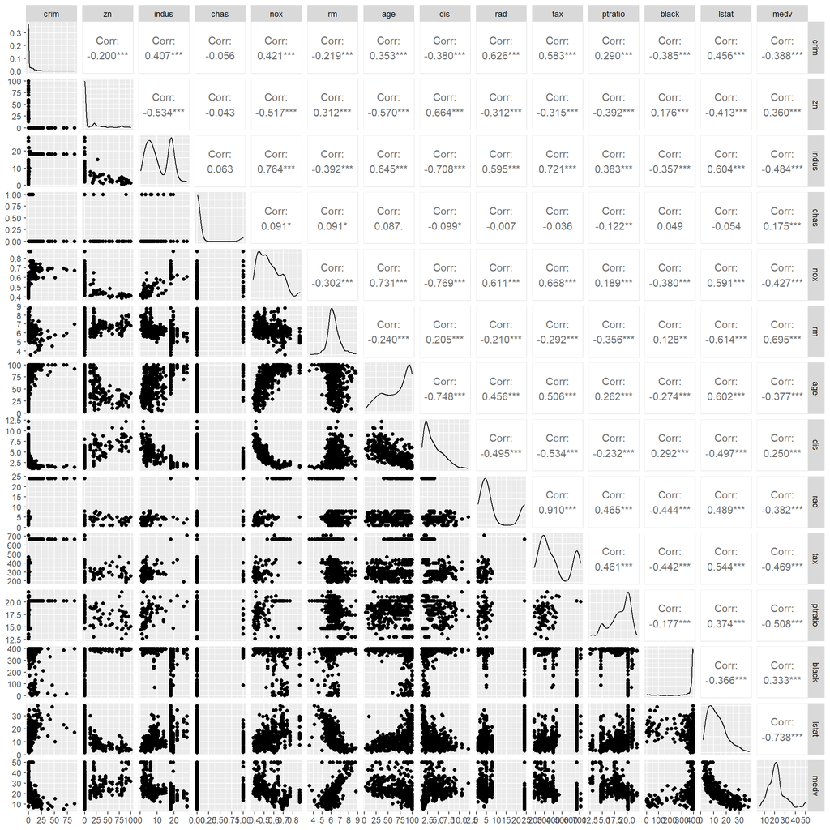

```r
ggpairs(Boston, lower = list(combo = wrap("facethist", bins = 20)))
```

```r
#Standardize the dataset
boston_scaled <- scale(Boston)


#Change from object
boston_scaled <- as.data.frame(boston_scaled)
#See the change
summary(boston_scaled)
```

```
##       crim                 zn               indus              chas
##  Min.   :-0.419367   Min.   :-0.48724   Min.   :-1.5563   Min.   :-0.2723
##  1st Qu.:-0.410563   1st Qu.:-0.48724   1st Qu.:-0.8668   1st Qu.:-0.2723
##  Median :-0.390280   Median :-0.48724   Median :-0.2109   Median :-0.2723
##  Mean   : 0.000000   Mean   : 0.00000   Mean   : 0.0000   Mean   : 0.0000
##  3rd Qu.: 0.007389   3rd Qu.: 0.04872   3rd Qu.: 1.0150   3rd Qu.:-0.2723
##  Max.   : 9.924110   Max.   : 3.80047   Max.   : 2.4202   Max.   : 3.6648
##       nox                rm               age               dis
##  Min.   :-1.4644   Min.   :-3.8764   Min.   :-2.3331   Min.   :-1.2658
##  1st Qu.:-0.9121   1st Qu.:-0.5681   1st Qu.:-0.8366   1st Qu.:-0.8049
##  Median :-0.1441   Median :-0.1084   Median : 0.3171   Median :-0.2790
##  Mean   : 0.0000   Mean   : 0.0000   Mean   : 0.0000   Mean   : 0.0000
##  3rd Qu.: 0.5981   3rd Qu.: 0.4823   3rd Qu.: 0.9059   3rd Qu.: 0.6617
##  Max.   : 2.7296   Max.   : 3.5515   Max.   : 1.1164   Max.   : 3.9566
##       rad               tax             ptratio            black
##  Min.   :-0.9819   Min.   :-1.3127   Min.   :-2.7047   Min.   :-3.9033
##  1st Qu.:-0.6373   1st Qu.:-0.7668   1st Qu.:-0.4876   1st Qu.: 0.2049
##  Median :-0.5225   Median :-0.4642   Median : 0.2746   Median : 0.3808
##  Mean   : 0.0000   Mean   : 0.0000   Mean   : 0.0000   Mean   : 0.0000
##  3rd Qu.: 1.6596   3rd Qu.: 1.5294   3rd Qu.: 0.8058   3rd Qu.: 0.4332
##  Max.   : 1.6596   Max.   : 1.7964   Max.   : 1.6372   Max.   : 0.4406
##      lstat              medv
##  Min.   :-1.5296   Min.   :-1.9063
##  1st Qu.:-0.7986   1st Qu.:-0.5989
##  Median :-0.1811   Median :-0.1449
##  Mean   : 0.0000   Mean   : 0.0000
##  3rd Qu.: 0.6024   3rd Qu.: 0.2683
##  Max.   : 3.5453   Max.   : 2.9865
```

After data transformation with scaling the data the range of data values do not differ so widely.

Next we will create a categorical variable of the crime rate and use the quantiles as the break points.

```r
#Create a quantile vector of crim rate
bins <- quantile(boston_scaled$crim)
bins
```

```
##           0%          25%          50%          75%         100%
## -0.419366929 -0.410563278 -0.390280295  0.007389247  9.924109610
```

```r
#Add new variable
boston_scaled$crime <- cut(boston_scaled$crim, breaks = bins, include.lowest = TRUE, labels = c("low", "med_low", "med_high", "high"))

library(dplyr)
#Remove the old variable
boston_scaled <- dplyr::select(boston_scaled, -crim)
```

Here I divide the dataset to train (with 80% of the data) and test set.

```r
n <- nrow(boston_scaled)

#Choose randomly 80% of data
ind <- sample(n,  size = n * 0.8)

#Create train set
train <- boston_scaled[ind,]
#Create test set
test <- boston_scaled[-ind,]
```

## Linear discriminant analysis

Here I will fit the linear discriminant analysis on the train set and draw the LDA (bi)plot. Crime rate will be used as the categorical target variable and all the other variables in the dataset as predictor variables.

```r
# Fit the analysis
lda.fit <- lda(crime ~ ., data = train)

# print the analysis result
lda.fit
```

```
## Call:
## lda(crime ~ ., data = train)
##
## Prior probabilities of groups:
##       low   med_low  med_high      high
## 0.2475248 0.2549505 0.2500000 0.2475248
##
## Group means:
##                  zn      indus       chas        nox         rm        age
## low       0.8942612 -0.9113786 -0.1148451 -0.8718164  0.4770103 -0.8544538
## med_low  -0.1182054 -0.2783239 -0.1194320 -0.5417155 -0.1666079 -0.2846913
## med_high -0.3675238  0.1500303  0.1954452  0.3883234  0.0647639  0.3756672
## high     -0.4872402  1.0171519 -0.1148451  1.0680654 -0.4633311  0.8390428
##                 dis        rad        tax     ptratio       black       lstat
## low       0.7788813 -0.6821213 -0.7471182 -0.44737089  0.38233332 -0.77866060
## med_low   0.3351424 -0.5380946 -0.4255020 -0.06197587  0.32324203 -0.08495312
## med_high -0.3704350 -0.4144603 -0.3333844 -0.36590632  0.07634308  0.04454868
## high     -0.8832738  1.6377820  1.5138081  0.78037363 -0.65818633  0.94060760
##                 medv
## low       0.56324182
## med_low  -0.04547553
## med_high  0.19505339
## high     -0.71759613
##
## Coefficients of linear discriminants:
##                  LD1         LD2         LD3
## zn       0.090055842  0.72352551 -0.95328911
## indus   -0.005426749 -0.29995789  0.15580342
## chas    -0.026178427 -0.02126341 -0.03769429
## nox      0.453493019 -0.83216527 -1.30240640
## rm       0.015248758 -0.02564750 -0.17778694
## age      0.242418713 -0.27942761  0.05638201
## dis     -0.066122378 -0.36248956  0.35831864
## rad      3.189102360  0.86489304 -0.43957012
## tax     -0.043110286  0.10090158  1.01624904
## ptratio  0.163404223  0.02839849 -0.29601748
## black   -0.122118763  0.03873554  0.10621584
## lstat    0.250661167 -0.26882572  0.39364075
## medv     0.144974130 -0.46954208 -0.12875065
##
## Proportion of trace:
##    LD1    LD2    LD3
## 0.9486 0.0370 0.0144
```

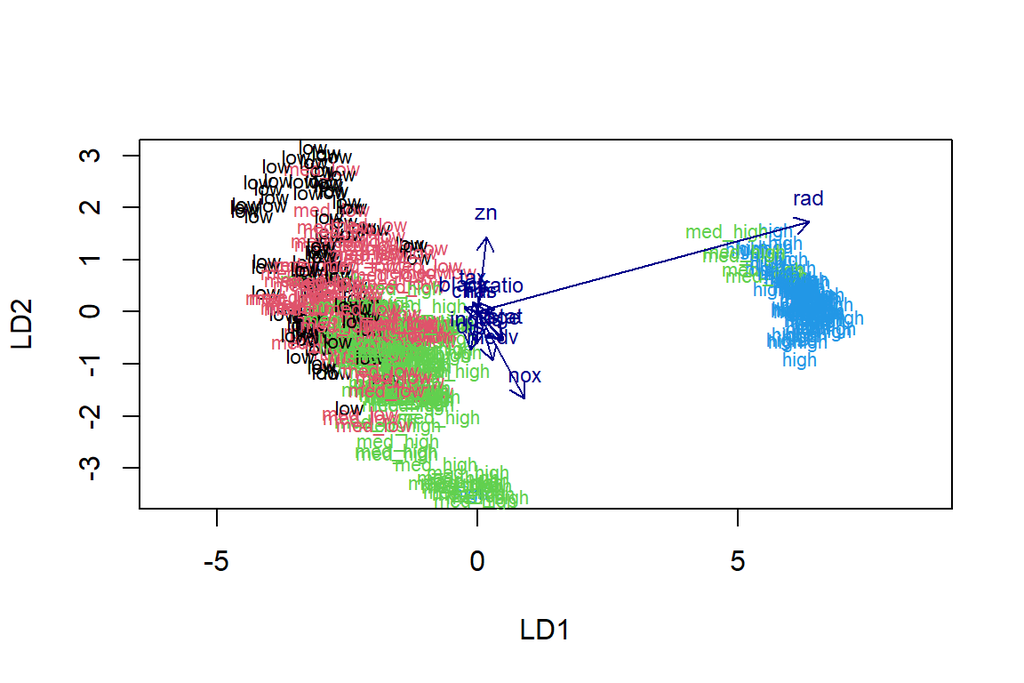

```r
# the function for lda biplot arrows
lda.arrows <- function(x, myscale = 1, arrow_heads = 0.1, color = "blue4", tex = 0.75, choices = c(1,2)){
  heads <- coef(x)
  arrows(x0 = 0, y0 = 0,
         x1 = myscale * heads[,choices[1]],
         y1 = myscale * heads[,choices[2]], col=color, length = arrow_heads)
  text(myscale * heads[,choices], labels = row.names(heads),
       cex = tex, col=color, pos=3)
}

# target classes as numeric
classes <- as.numeric(train$crime)

# plot the lda results
plot(lda.fit, dimen = 2, col = classes, pch = classes)
lda.arrows(lda.fit, myscale = 2)
```

Based on the biplot, *high* separated very clearly. Based on arrows, *rad* index of accessibility to radial highways explained more for *high* values than for others. There is an overlap between *low*,*med_low*, *med_high*.

### Cross-tabulation with test set

Now we will cross tabulate the results with the crime categories from the test set.

```r
#Obtain the true classes for the variables of test dataset
correct_classes <- test$crime

#Remove the crime classes from test data set
test <- dplyr::select(test, -crime)

#Predict classes with the fitted linear discriminant analysis
lda.pred <- predict(lda.fit, newdata = test)

#Cross tabulate the results with the crime categories from the test set
table(correct = correct_classes, predicted = lda.pred$class)
```

```
##           predicted
## correct    low med_low med_high high
##   low       17       8        2    0
##   med_low    8      12        3    0
##   med_high   0       9       15    1
##   high       0       0        0   27
```

### Optimal number of clusters

Further we will investigate what would have been the optimal number of clusters.

```r
#Make a new scaled version of the dataset
library(MASS)
data("Boston")
boston_scaled2 <- scale(Boston)

#Calculate euclidean distance
dist_eu <- dist(boston_scaled2)

#Summary of the distances
summary(dist_eu)
```

```
##    Min. 1st Qu.  Median    Mean 3rd Qu.    Max.
##  0.1343  3.4625  4.8241  4.9111  6.1863 14.3970
```

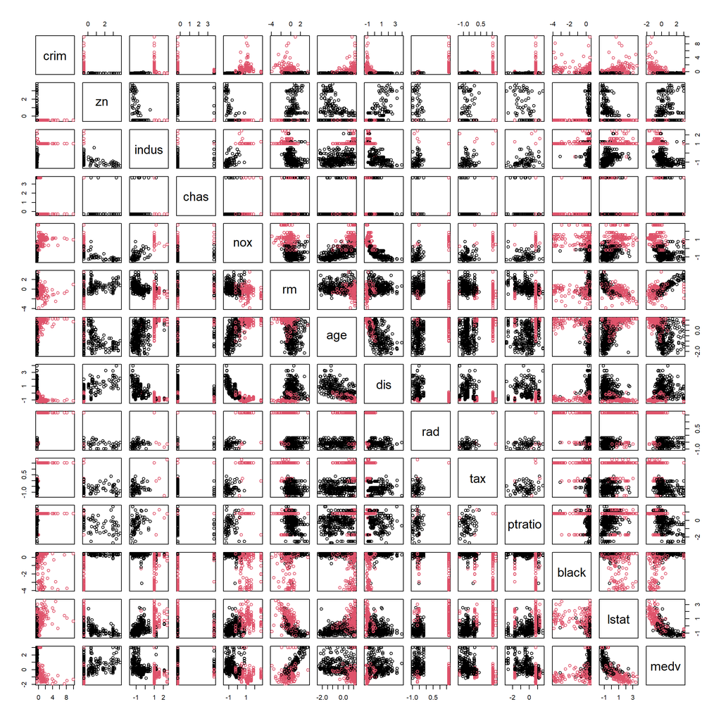

```r
km <-kmeans(boston_scaled2, centers = 2)

#Datapoints divided  in 2 clusters
pairs(boston_scaled2, col = km$cluster)
```

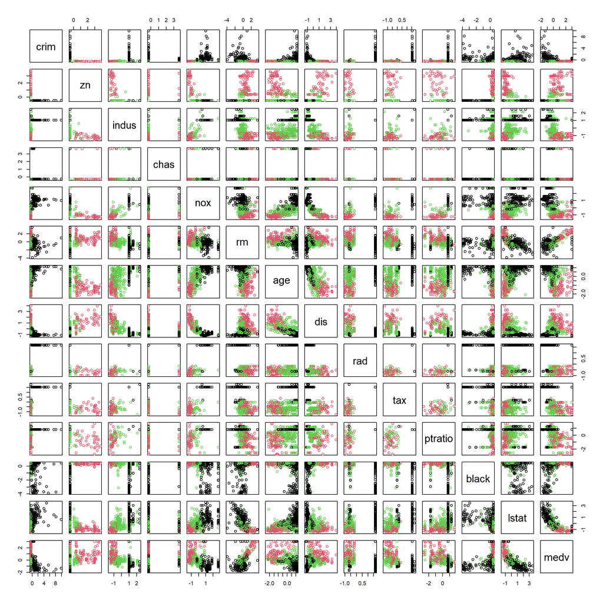

```r
km <-kmeans(boston_scaled2, centers = 3)

#Datapoints divided in 3 clusters
pairs(boston_scaled2, col = km$cluster)
```

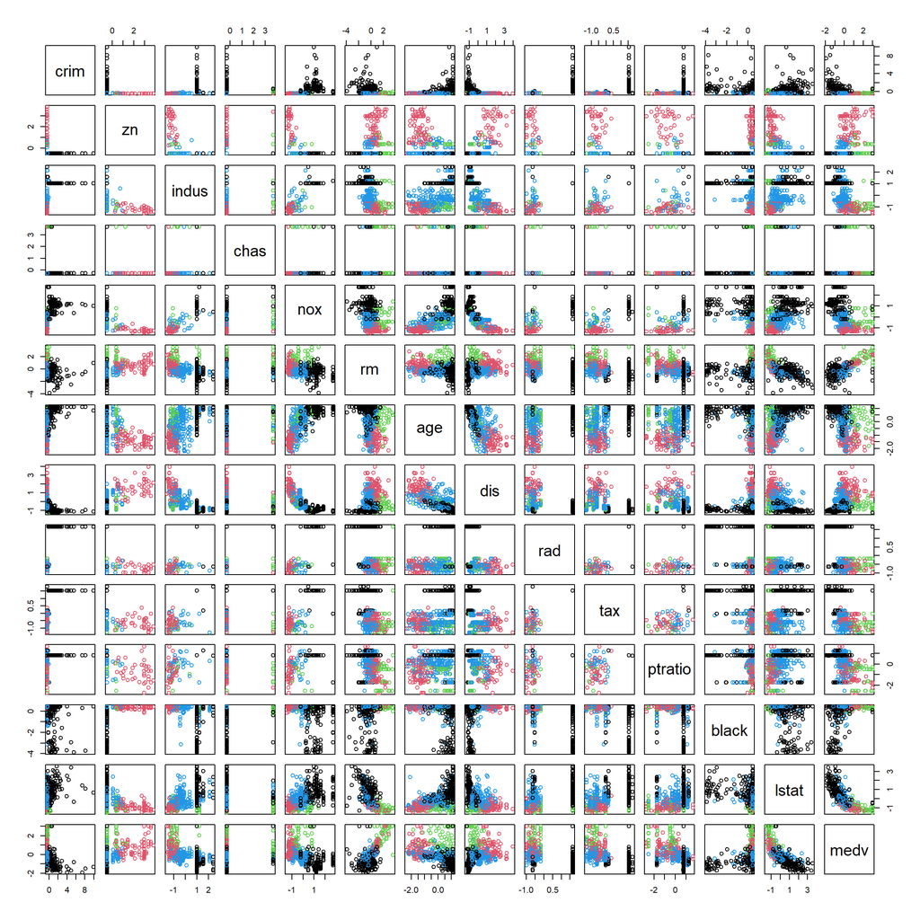

```r
km <-kmeans(boston_scaled2, centers = 4)

#Datapoints divided in 4 clusters
pairs(boston_scaled2, col = km$cluster)
```

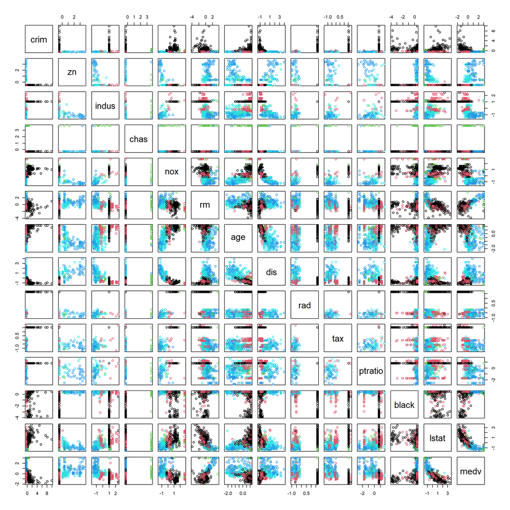

```r
km <-kmeans(boston_scaled2, centers = 5)

#Datapoints divided in 5 clusters
pairs(boston_scaled2, col = km$cluster)
```

As it is hard to visually determine the number of clusters, I will compare the sum of squared error (SSE) for a number of cluster solutions to choose the appropriate number of clusters.

```r
library(factoextra)
```

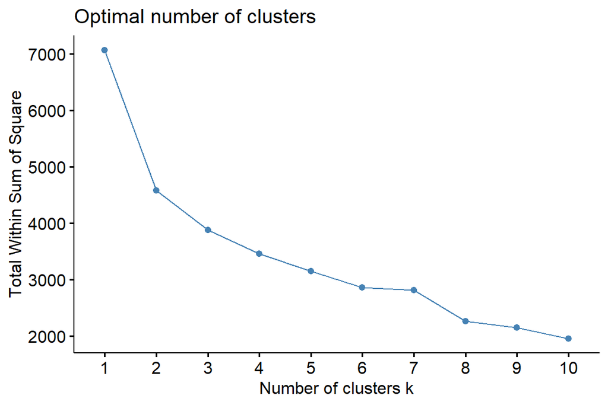

```r
fviz_nbclust(boston_scaled2, kmeans, method = "wss")
```

Lets determine the number clusters according to the Bayesian Information Criterion for expectation-maximization here:

```r
library(mclust)
# Run the function to see how many clusters (from 1 to 20)
d_clust <- Mclust(as.matrix(boston_scaled2), G=1:20)
m.best <- dim(d_clust$z)[2]
cat("model-based optimal number of clusters:", m.best, "\n")
```

```
## model-based optimal number of clusters: 5
```

Thus we can conclude that the data could be well divided in 5 clusters.